# Profil Amplitude - Fréquence

Observation

Auteur·rice

Robin Maël

Date de publication

4 avril 2026

Mots clés

Amplitude, Fréquence, Sprint, Optimisation

# Profil Amplitude-Fréquence

**Observations générales**

**Statistiques Descriptives**

**Population**

Tableau n°0 : Description de ma population

[output not shown]

**All**

Tableau n°1 : Statistiques Descriptives Générales de la Vitesse (m.s)

| Catégorie | Nombre d'Observations | Moyenne | Minimum | Maximum | Écart_type | Coeff_Variance (%) |
| --- | --- | --- | --- | --- | --- | --- |
| Guide | 317 | 8.44 | 2.70 | 10.20 | ± 1.09 | 12.86 |
| Para | 1393 | 6.89 | 3.50 | 9.62 | ± 0.91 | 13.21 |
| Valide | 482 | 8.16 | 3.84 | 10.64 | ± 1.25 | 15.36 |

Tableau n°2 : Statistiques Descriptives Générales de l’Amplitude (m)

| Catégorie | Nombre d'Observations | Moyenne | Minimum | Maximum | Écart_type | Coeff_Variance (%) |
| --- | --- | --- | --- | --- | --- | --- |
| Guide | 317 | 2.09 | 0.77 | 2.50 | ± 0.24 | 11.53 |
| Para | 1392 | 1.77 | 0.91 | 2.25 | ± 0.18 | 10.01 |
| Valide | 482 | 2.06 | 1.22 | 2.50 | ± 0.26 | 12.74 |

Tableau n°3 : Statistiques Descriptives Générales de la Fréquence (Hz)

| Catégorie | Nombre d'Observations | Moyenne | Minimum | Maximum | Écart_type | Coeff_Variance (%) |
| --- | --- | --- | --- | --- | --- | --- |
| Guide | 317 | 4.05 | 3.15 | 5.45 | ± 0.26 | 6.30 |
| Para | 1392 | 3.89 | 3.07 | 5.03 | ± 0.34 | 8.63 |
| Valide | 482 | 3.97 | 2.44 | 4.92 | ± 0.44 | 11.03 |

Ces tableaux sont des statistiques descriptives de toutes les données que j’ai pu prendre en 3 ans. Attention pas de distinction entre les différentes phases de sprint chez les Paras. Ce qui explique des statistiques descriptives très différentes.

**Valides**

Tableau n°4 : Statistiques Descriptives Filtrées de la Vitesse (m.s)

| Sexe | Nombre d'Observations | Moyenne | Minimum | Maximum | Écart_type | Coeff_Variance (%) |
| --- | --- | --- | --- | --- | --- | --- |
| F | 95 | 7.74 | 5.26 | 9.48 | ± 0.92 | 11.87 |
| M | 121 | 8.68 | 5.98 | 10.31 | ± 1.11 | 12.73 |

Tableau n°5 : Statistiques Descriptives Filtrées de l’Amplitude (m)

| Sexe | Nombre d'Observations | Moyenne | Minimum | Maximum | Écart_type | Coeff_Variance (%) |
| --- | --- | --- | --- | --- | --- | --- |
| F | 95 | 2.06 | 1.68 | 2.41 | ± 0.13 | 6.25 |
| M | 121 | 2.18 | 1.80 | 2.44 | ± 0.13 | 5.87 |

Tableau n°6 : Statistiques Descriptives Filtrées de la Fréquence (Hz)

[output not shown]

Tableau n°7 : Statistiques Descriptives Filtrées du Temps de Contact (s)

| Sexe | Nombre d'Observations | Moyenne | Minimum | Maximum | Écart_type | Coeff_Variance (%) |
| --- | --- | --- | --- | --- | --- | --- |
| F | 43 | 0.121 | 0.090 | 0.174 | ± 0.018 | 14.892 |
| M | 35 | 0.117 | 0.085 | 0.150 | ± 0.016 | 13.453 |

Tableau n°8 : Statistiques Descriptives Filtrées du Temps d’Envol (s)

| Sexe | Nombre d'Observations | Moyenne | Minimum | Maximum | Écart_type | Coeff_Variance (%) |
| --- | --- | --- | --- | --- | --- | --- |
| F | 43 | 0.149 | 0.124 | 0.188 | ± 0.017 | 11.047 |
| M | 35 | 0.156 | 0.121 | 0.192 | ± 0.019 | 12.128 |

Ici les statistiques sont beaucoup plus homogène car c’est uniquement les athlètes que j’ai observé cette année à vitesse constante.

(Rajouter les stats d’amplitude relative) + modifier la colonne de la fréquence vers la fréquence inverse

**Distribution**

**Normalité**

**Paras**

Tableau n°9 : Tests de Normalité sur les Paras

| Variable | W | p.value | Normalité |
| --- | --- | --- | --- |
| Vitesse (m.s) | 0.991 | 0 | Non normale ❌ \| |
| Amplitude (m) | 0.936 | 0 | Non normale ❌ \| |
| Fréquence (Hz) | 0.983 | 0 | Non normale ❌ \| |

Tableau n°10 : Normalité selon les athlètes Paras

| Prénom | Normalité_vit | Normalité_amp | Normalité_fre |
| --- | --- | --- | --- |
| Evan | Non normale ❌ \| | Non normale ❌ \| | Normale ✅ \| |
| Lucile | Non normale ❌ \| | Non normale ❌ \| | on normale ❌ \| |
| Tiffany | Non normale ❌ \| | Non normale ❌ \| | Normale ✅ \| |
| Trésor | Non normale ❌ \| | Non normale ❌ \| | on normale ❌ \| |

**Valides**

Tableau n°11 : Tests de Normalité sur les athlètes valides

| Variable | W | p.value | Normalité |
| --- | --- | --- | --- |
| Vitesse (m.s) | 0.993 | 0.553 | Normale ✅ \| |
| Amplitude (m) | 0.983 | 0.026 | Non normale ❌ \| |
| Fréquence (Hz) | 0.990 | 0.223 | Normale ✅ \| |
| Temps de Contact (s) | 0.964 | 0.028 | Non normale ❌ \| |
| Temps d'Envol (s) | 0.959 | 0.013 | Non normale ❌ \| |

Tableau n°12 : Normalité selon les athlètes valides

| Prénom | Normalité_vit | Normalité_amp | Normalité_fre |
| --- | --- | --- | --- |
| Chloé | Normale ✅ \| | Normale ✅ \| | Normale ✅ \| |
| Chris | Non normale ❌ \| | Normale ✅ \| | Normale ✅ \| |
| Dylan | Normale ✅ \| | Normale ✅ \| | on normale ❌ \| |
| Enzo | Non normale ❌ \| | Normale ✅ \| | Normale ✅ \| |
| Estelle | Normale ✅ \| | Normale ✅ \| | Normale ✅ \| |
| Grace | Normale ✅ \| | Normale ✅ \| | Normale ✅ \| |
| Johanna | Normale ✅ \| | Normale ✅ \| | Normale ✅ \| |
| Mahine-Ruth | Normale ✅ \| | Non normale ❌ \| | Normale ✅ \| |
| Matteo | Non normale ❌ \| | Normale ✅ \| | Normale ✅ \| |
| Oumar | Normale ✅ \| | Normale ✅ \| | Normale ✅ \| |
| Sessia | Normale ✅ \| | Normale ✅ \| | Normale ✅ \| |
| Yacouba | Normale ✅ \| | Normale ✅ \| | Normale ✅ \| |

**Visualisations**

**Paras**

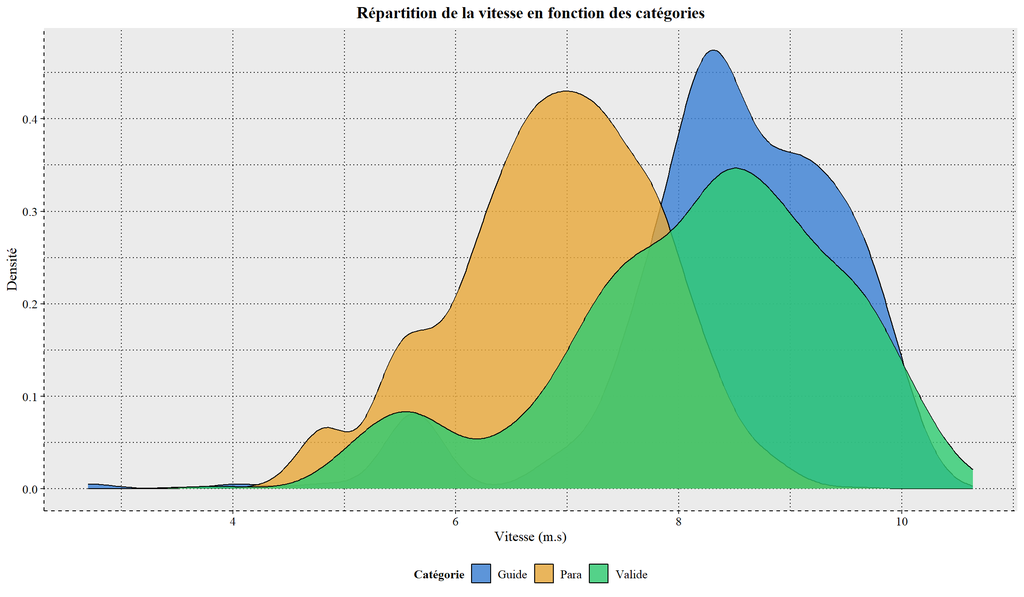

Graphique n°1 : Répartition de la vitesse en fonction des catégories

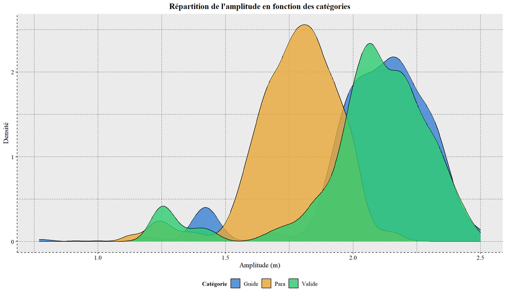

Graphique n°2 : Répartition de l’amplitude en fonction des catégories

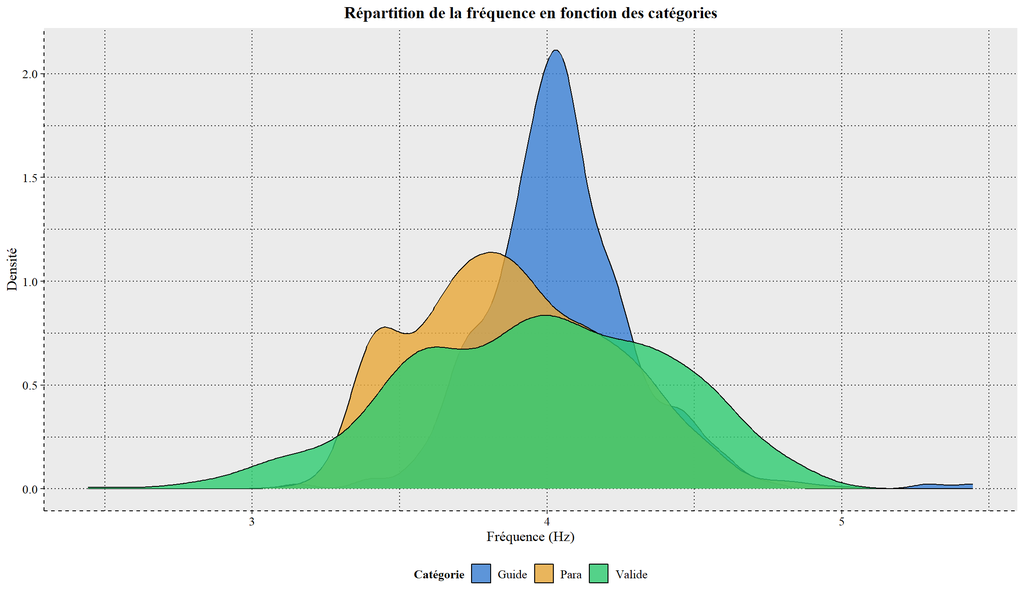

Graphique n°3 : Répartition de la fréquence en fonction des catégories

**Valides**

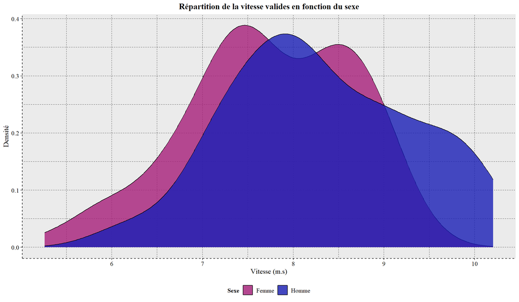

Graphique n°4 : Répartition de la vitesse valides en fonction du sexe

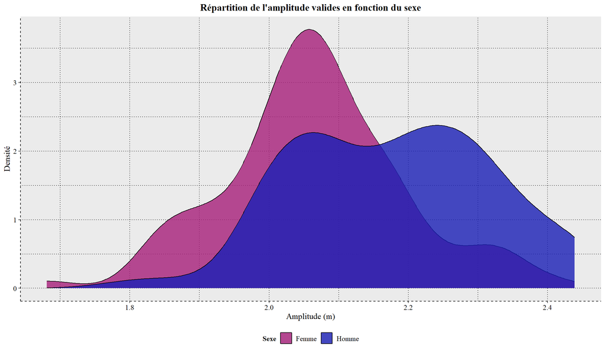

Graphique n°5 : Répartition de l’amplitude valides en fonction du sexe

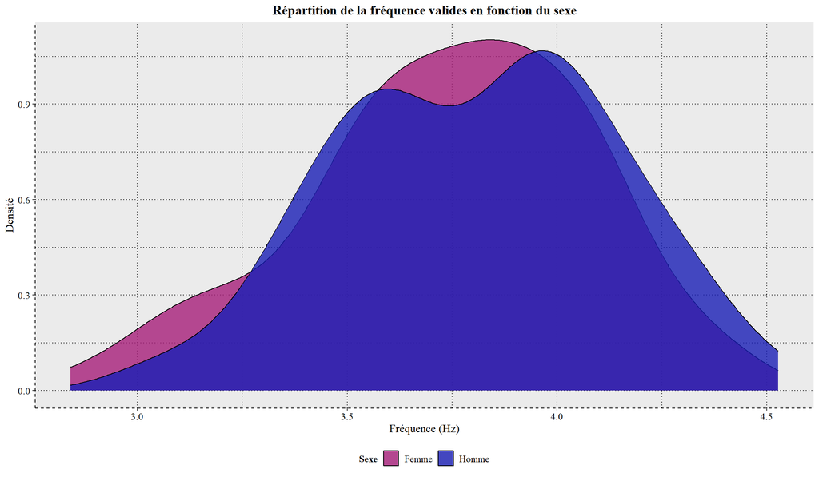

Graphique n°6 : Répartition de la fréquence valides en fonction du sexe

**Observations Graphiques**

**All**

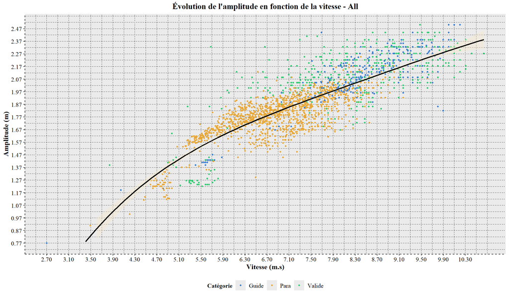

Graphique n°7 : Évolution de l’amplitude en fonction de la vitesse - All

On note un ρ = 0.83***.

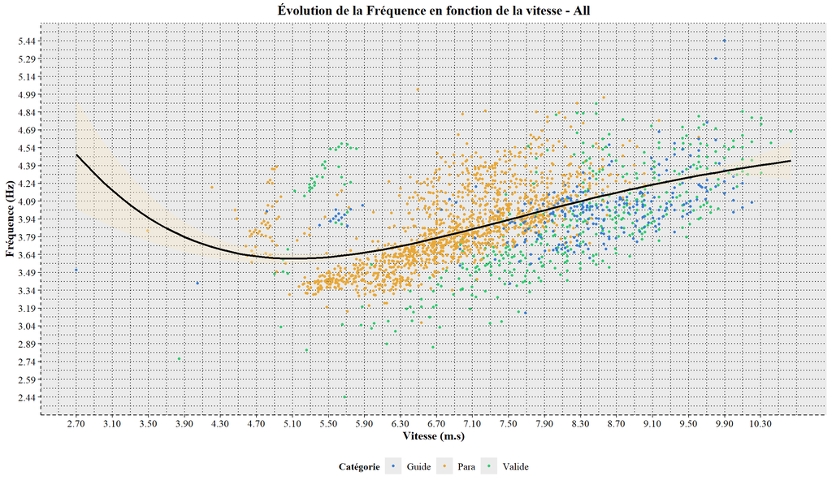

Graphique n°8 : Évolution de la Fréquence en fonction de la vitesse - All

On note un r² de ρ = 0.48***.

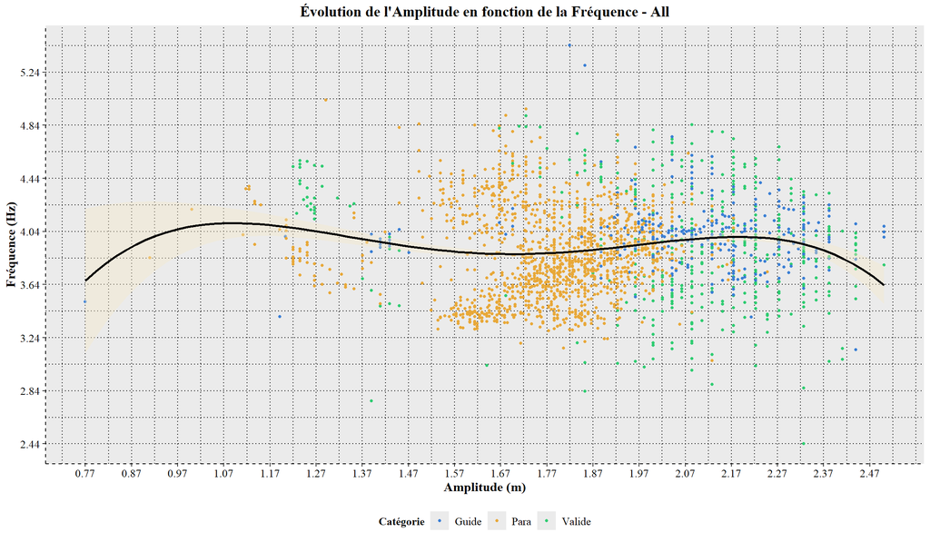

Graphique n°9 : Évolution de l’Amplitude en fonction de la Fréquence - All

On note un r² de ρ = -0.08ns.

**Filtré**

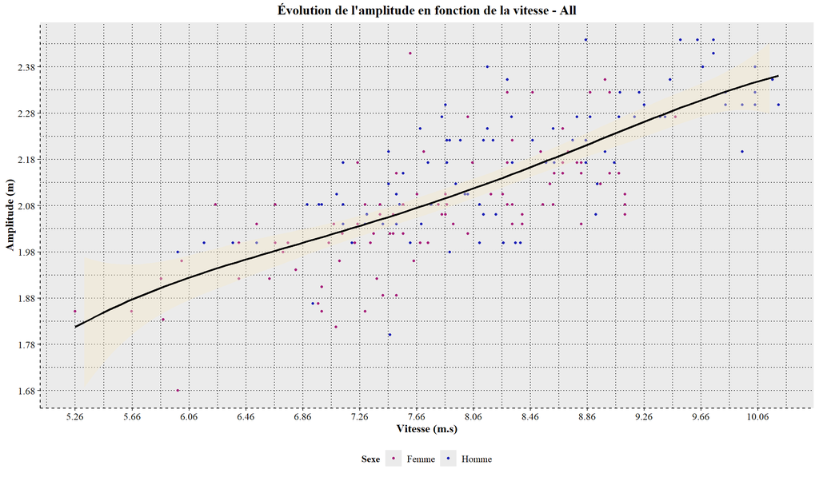

Graphique n°10 : Évolution de l’amplitude en fonction de la vitesse - Filtré

On note un ρ = 0.84***.

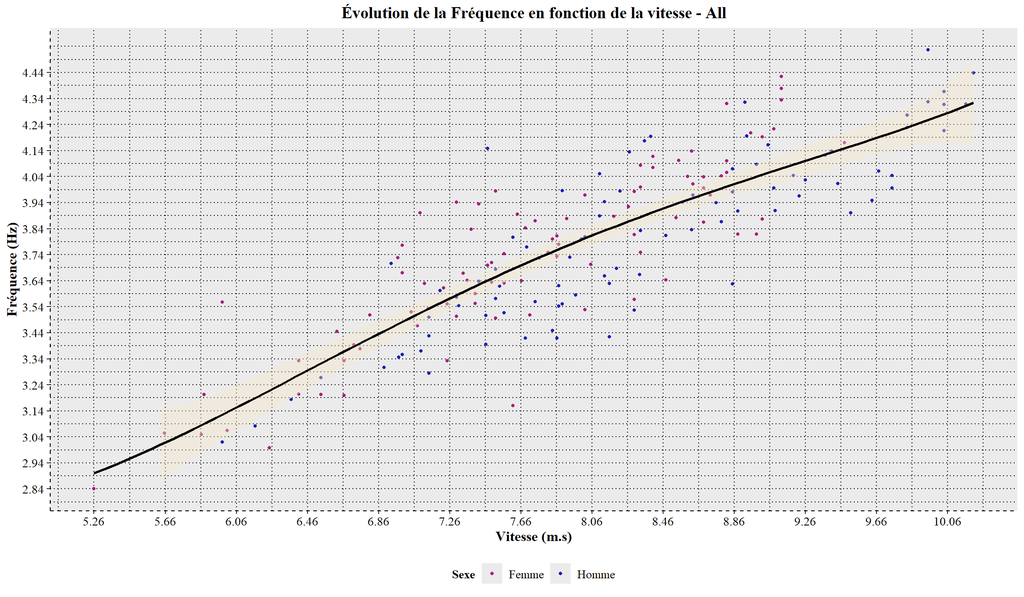

Graphique n°11 : Évolution de la Fréquence en fonction de la vitesse - Filtré

On note un r² de ρ = 0.84***.

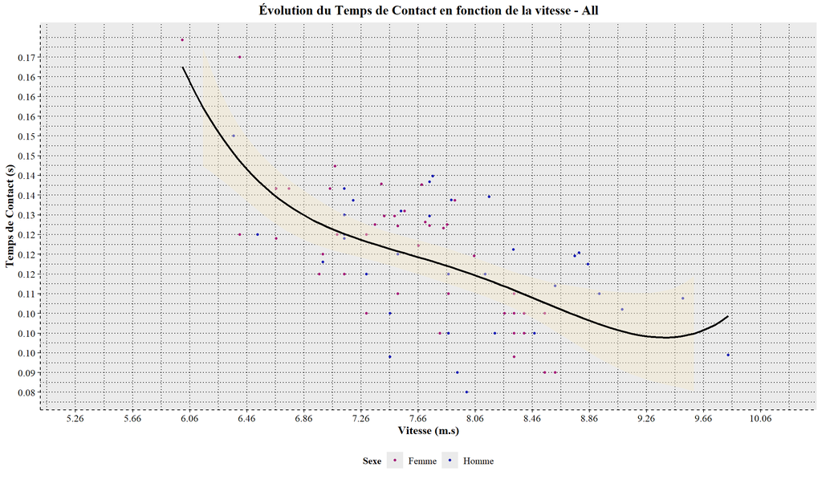

Graphique n°12 : Évolution du Temps de Contact en fonction de la vitesse - Filtré

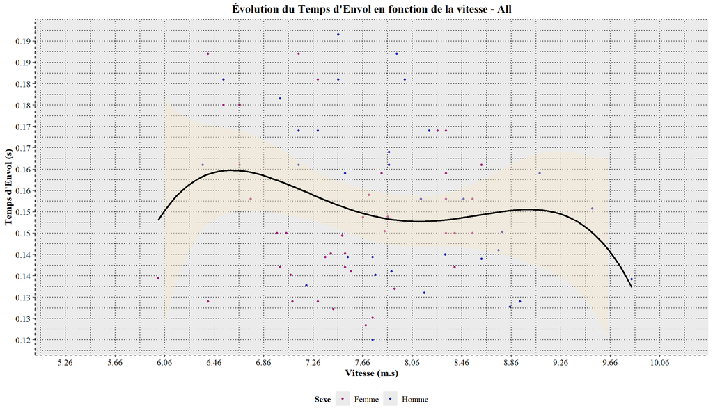

Graphique n°13 : Évolution du Temps d’Envol en fonction de la vitesse - Filtré

**Athlètes**

**Paras**

**Lucile**

##### Observation

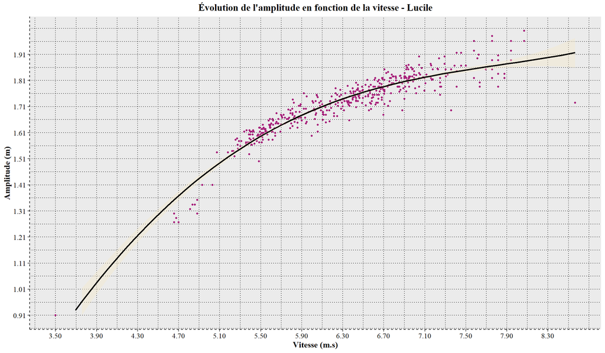

Graphique n°14 : Évolution de l’amplitude en fonction de la vitesse - Lucile

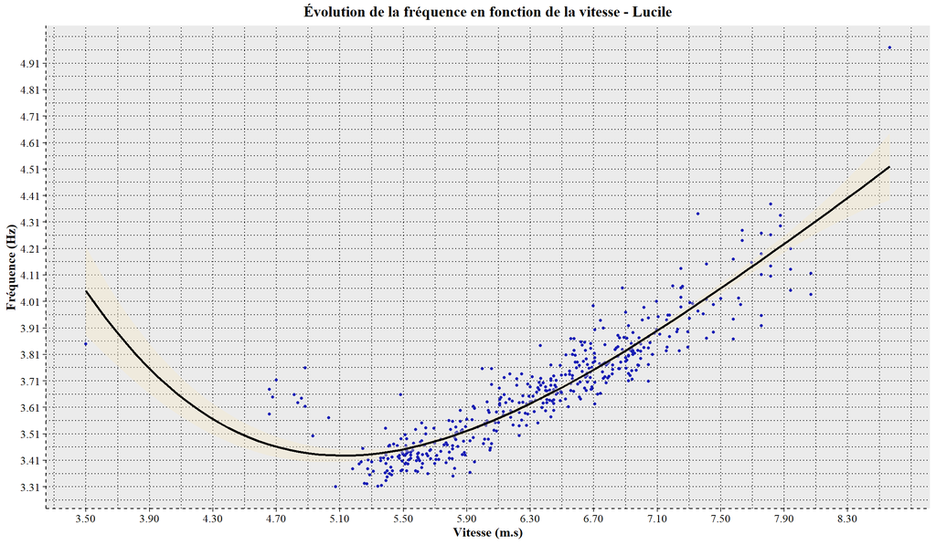

Graphique n°15 : Évolution de la fréquence en fonction de la vitesse - Lucile

**Tiffany**

##### Observation

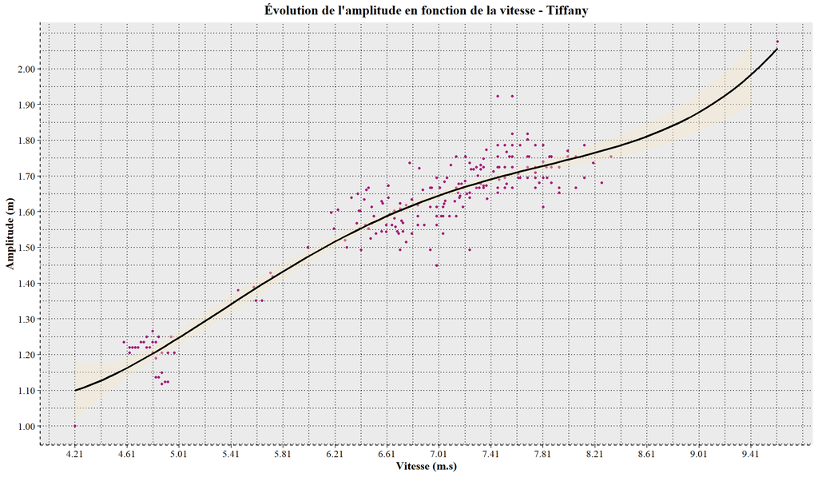

Graphique n°16 : Évolution de l’amplitude en fonction de la vitesse - Tiffany

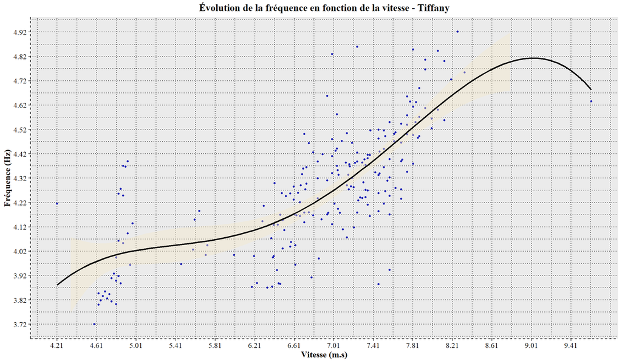

Graphique n°17 : Évolution de la fréquence en fonction de la vitesse - Tiffany

**Evan**

##### Observation

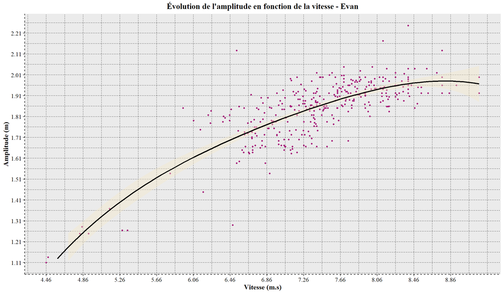

Graphique n°18 : Évolution de l’amplitude en fonction de la vitesse - Evan

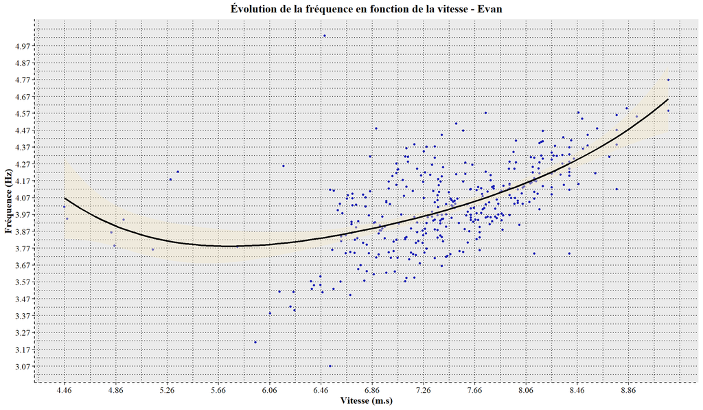

Graphique n°19 : Évolution de la fréquence en fonction de la vitesse - Evan

**Trésor**

##### Observation

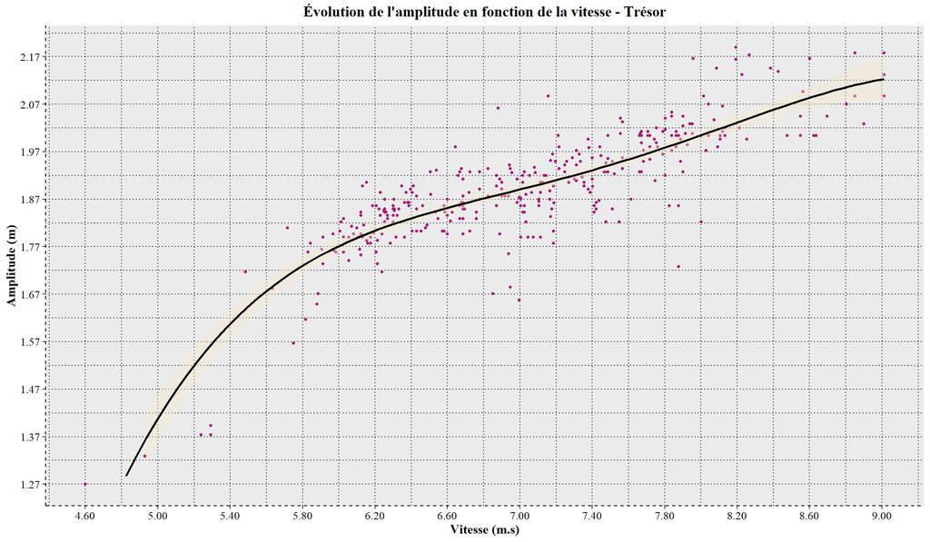

Graphique n°20 : Évolution de l’amplitude en fonction de la vitesse - Trésor

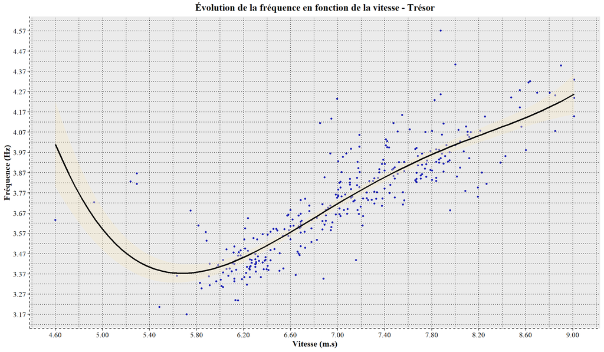

Graphique n°21 : Évolution de la fréquence en fonction de la vitesse - Trésor

**Guides**

**Lucas**

###### Observations

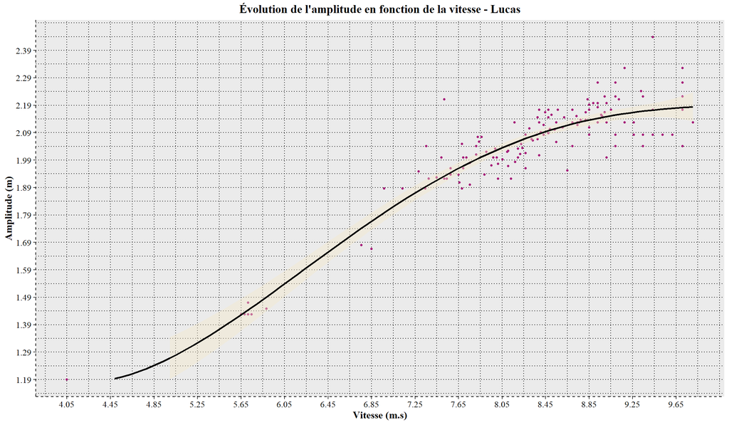

Graphique n°22 : Évolution de l’amplitude en fonction de la vitesse - Lucas

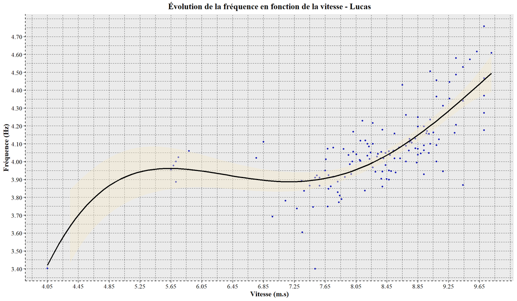

Graphique n°23 : Évolution de la fréquence en fonction de la vitesse - Lucas

**Joachim**

###### Observations

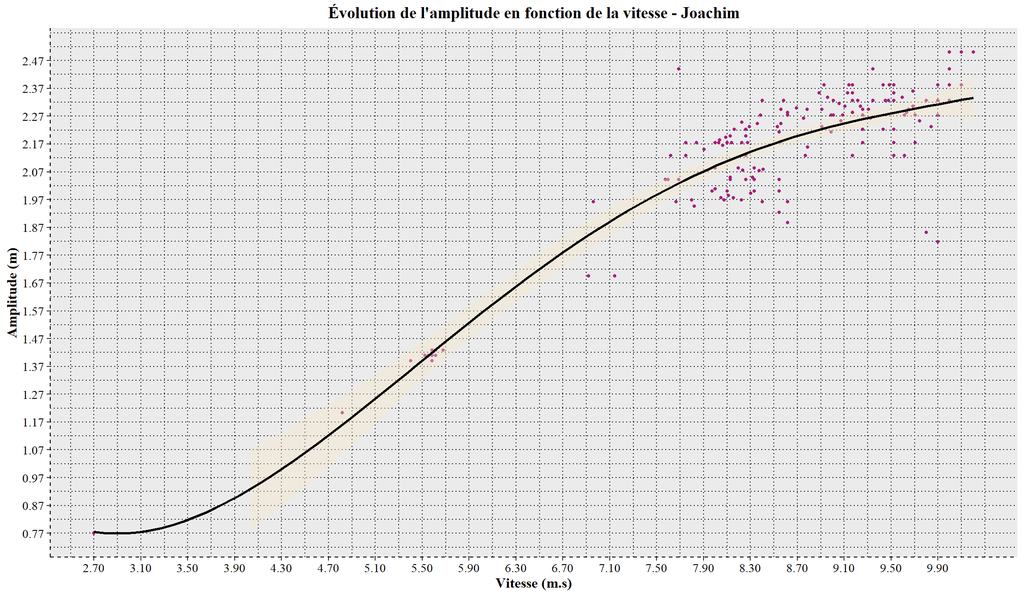

Graphique n°24 : Évolution de l’amplitude en fonction de la vitesse - Joachim

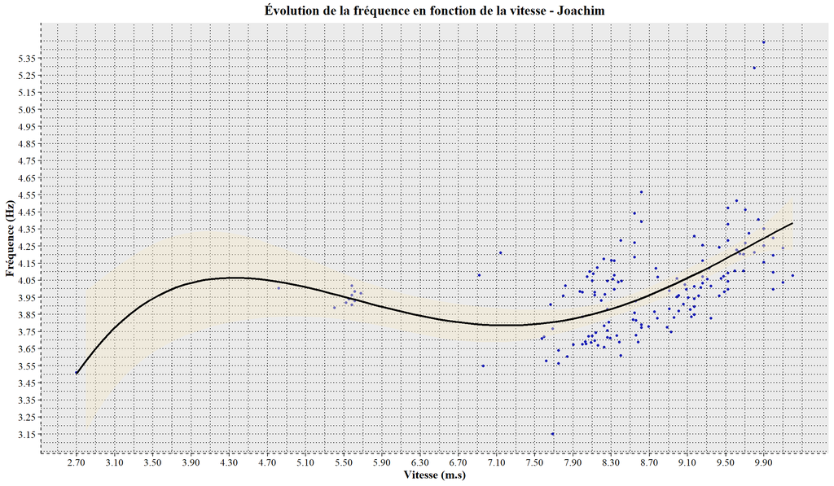

Graphique n°25 : Évolution de la fréquence en fonction de la vitesse - Joachim

**Valides**

**Chris**

##### Observation

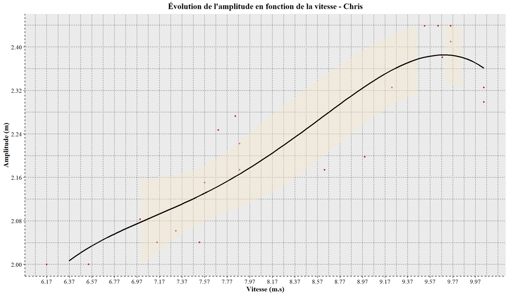

Graphique n°26 : Évolution de l’amplitude en fonction de la vitesse - Chris

On note un ρ = 0.9***.

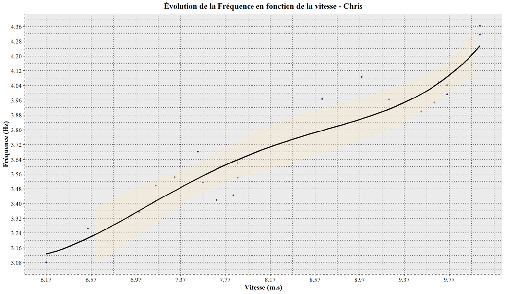

Graphique n°27 : Évolution de la Fréquence en fonction de la vitesse - Chris

On note un r² de ρ = 0.94***.

**Sessia**

##### Observation

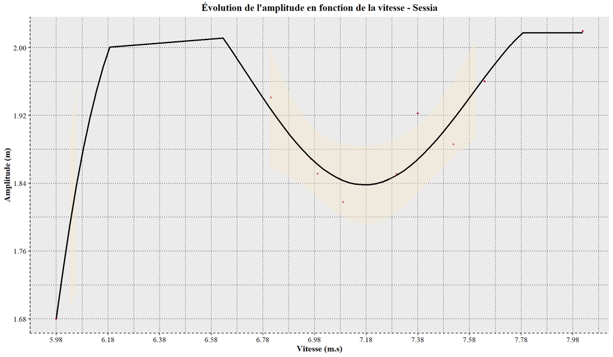

Graphique n°28 : Évolution de l’amplitude en fonction de la vitesse - Sessia

On note un ρ = 0.85**.

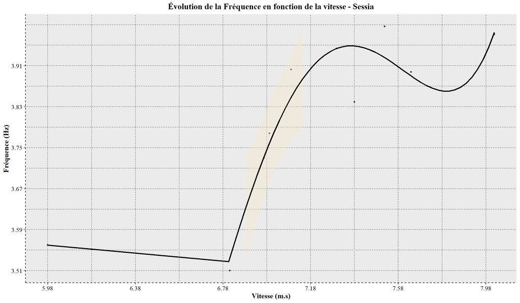

Graphique n°29 : Évolution de la Fréquence en fonction de la vitesse - Sessia

On note un r² de ρ = 0.82**.

**Enzo**